# Practical Machine Learning

Suyash

10/12/2020

## Overview

Using devices such as Goqii, Amazfit , and Fitbit devices, a large amount of fitness data of millions of individuals is being uploaded everyday .The manner in which individuals perform a barbell lift is what we are trying to access with this project. The data comes from http://groupware.les.inf.puc-rio.br/har wherein 6 participants were asked to perform the same set of exercises correctly and incorrectly with accelerometers placed on the belt, forearm, arm, and dumbell.

## Data

The training data for this project are available here: https://d396qusza40orc.cloudfront.net/predmachlearn/pml-training.csv The test data are available here: https://d396qusza40orc.cloudfront.net/predmachlearn/pml-testing.csv The data for this project come from this source: http://web.archive.org/web/20161224072740/http:/groupware.les.inf.puc-rio.br/har

## L_oading_packages

```r
library(caret)
```

```r
library(rpart)
library(rpart.plot)
library(ggplot2)
library(corrplot)
library(randomForest)
library(rattle)
set.seed(21345)
```

## Loading_Data_&_Partitioning

```r
t_raining <- read.csv(url("https://d396qusza40orc.cloudfront.net/predmachlearn/pml-training.csv"))
t_esting <- read.csv(url("https://d396qusza40orc.cloudfront.net/predmachlearn/pml-testing.csv"))

l_abel <- createDataPartition(t_raining$classe, p = 0.7, list = FALSE)
t_rain <- t_raining[l_abel, ]
t_est <- t_raining[-l_abel, ]
```

## D_ata_Cleaning

Removing missing values and variables with zero variance from the dataset.also removing identification vars.

```r
N_ZV <- nearZeroVar(t_rain)
t_rain <- t_rain[ ,-N_ZV]
t_est <- t_est[ ,-N_ZV]
l_abel <- apply(t_rain, 2, function(x) mean(is.na(x))) > 0.95
t_rain <- t_rain[, -which(l_abel, l_abel == FALSE)]
t_est <- t_est[, -which(l_abel, l_abel == FALSE)]
t_rain <- t_rain[ , -(1:5)]
t_est <- t_est[ , -(1:5)]
```

we know have 54 variables down from 160.

## Explo_ratory__Analysis

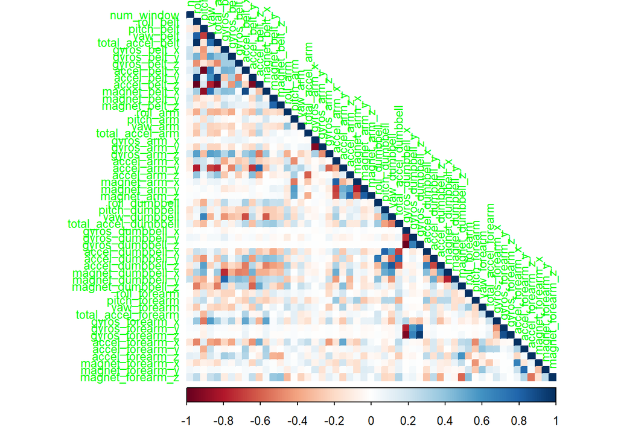

```r
corrMat <- cor(t_rain[,-54])
corrplot(corrMat, method = "color", type = "lower", tl.cex = 0.8, tl.col = rgb(0,1,0))
```

Darker gradient indicates high correlation in the figure above. performing a Principal Component Analysis in order to reduce correlated variables further but decided against doing that due to the number of correlations being quite few.

## Trainin_Model

```r
m_odelDT <- rpart(classe ~ ., data = t_rain, method = "class")
p_redictDT <- predict(m_odelDT, t_est, type = "class")
c_onfMatDT <- confusionMatrix(p_redictDT, t_est$classe)
c_onfMatDT
```

```
## Confusion Matrix and Statistics
##
##           Reference
## Prediction    A    B    C    D    E
##          A 1419  141   13   57   51
##          B   60  634   43   64   67
##          C   16  144  827   97   24
##          D  171  214  143  693  154
##          E    8    6    0   53  786
##
## Overall Statistics
##
##                Accuracy : 0.7407
##                  95% CI : (0.7293, 0.7519)
##     No Information Rate : 0.2845
##     P-Value [Acc > NIR] : < 2.2e-16
##
##                   Kappa : 0.6728
##
##  Mcnemar's Test P-Value : < 2.2e-16
##
## Statistics by Class:
##
##                      Class: A Class: B Class: C Class: D Class: E
## Sensitivity            0.8477   0.5566   0.8060   0.7189   0.7264
## Specificity            0.9378   0.9507   0.9422   0.8614   0.9861
## Pos Pred Value         0.8441   0.7304   0.7464   0.5040   0.9215
## Neg Pred Value         0.9393   0.8993   0.9583   0.9399   0.9412
## Prevalence             0.2845   0.1935   0.1743   0.1638   0.1839
## Detection Rate         0.2411   0.1077   0.1405   0.1178   0.1336
## Detection Prevalence   0.2856   0.1475   0.1883   0.2336   0.1449
## Balanced Accuracy      0.8927   0.7537   0.8741   0.7901   0.8562
```

ii)Random_FOrest

```r
c_ontrol <- trainControl(method = "cv", number = 3, verboseIter=FALSE)
m_odelRF <- train(classe ~ ., data = t_rain, method = "rf", trControl =c_ontrol)
p_redictRF <- predict(m_odelRF, t_est)
c_onfMatRF <- confusionMatrix(p_redictRF, t_est$classe)
c_onfMatRF
```

```
## Confusion Matrix and Statistics
##
##           Reference
## Prediction    A    B    C    D    E
##          A 1673    1    0    0    0
##          B    1 1136    0    0    0
##          C    0    2 1026    2    0
##          D    0    0    0  962    4
##          E    0    0    0    0 1078
##
## Overall Statistics
##
##                Accuracy : 0.9983
##                  95% CI : (0.9969, 0.9992)
##     No Information Rate : 0.2845
##     P-Value [Acc > NIR] : < 2.2e-16
##
##                   Kappa : 0.9979
##
##  Mcnemar's Test P-Value : NA
##
## Statistics by Class:
##
##                      Class: A Class: B Class: C Class: D Class: E
## Sensitivity            0.9994   0.9974   1.0000   0.9979   0.9963
## Specificity            0.9998   0.9998   0.9992   0.9992   1.0000
## Pos Pred Value         0.9994   0.9991   0.9961   0.9959   1.0000
## Neg Pred Value         0.9998   0.9994   1.0000   0.9996   0.9992
## Prevalence             0.2845   0.1935   0.1743   0.1638   0.1839
## Detection Rate         0.2843   0.1930   0.1743   0.1635   0.1832
## Detection Prevalence   0.2845   0.1932   0.1750   0.1641   0.1832
## Balanced Accuracy      0.9996   0.9986   0.9996   0.9986   0.9982
```

we can see that Random_Forest method provides an accuracy that is much higher than the other method namely training model. So i will be using this method only for our next step which is prediction.

## P_redicting_Results

```r
p_redictRF <- predict(m_odelRF, t_esting)
p_redictRF
```

```
##  [1] B A B A A E D B A A B C B A E E A B B B
## Levels: A B C D E
```